# R Notebook

### Step 1: Processing and Filtering Housing Data

This code chunk loads housing, energy usage, and weather data from various sources, focusing particularly on refining and filtering housing data by specific county codes. It then saves the filtered dataset to a predefined location for further analysis, ensuring the dataset contains only relevant and essential attributes for subsequent processing steps.

```r
# Load the necessary library
library(arrow)
library(dplyr)
library(readr)

housing_data <- 'https://intro-datascience.s3.us-east-2.amazonaws.com/SC-data/static_house_info.parquet'
static_housing_data <- read_parquet(housing_data)

write.csv(static_housing_data, "C:/Users/sagar/Downloads/IDS Project/final code/static_house.csv", row.names = FALSE)

columns_to_include <- c("bldg_id", "in.sqft", "in.bedrooms", "in.city", "in.clothes_dryer", "in.clothes_washer", "in.cooking_range", "in.county", "in.dishwasher", "in.water_heater_fuel", "in.refrigerator", "in.vacancy_status", "in.income", "in.occupants", "in.heating_fuel", "in.heating_setpoint", "in.cooling_setpoint", "in.hvac_cooling_efficiency", "in.hvac_heating_efficiency"
)

cleaned_housing_data<-static_housing_data[,columns_to_include]

# Filter rows where 'in.county' is one of the specified values
county_filter <- c("G4500730", "G4500850", "G4500910")
filtered_housing_data <- cleaned_housing_data %>% filter(in.county %in% county_filter)


write.csv(filtered_housing_data, "C:/Users/sagar/Downloads/IDS Project/final code/Final_static_house.csv", row.names = FALSE)

# View the first few rows of the final data frame
head(filtered_housing_data)
```

|  | bldg_id | in.sqft | in.bedrooms | in.city | in.clothes_dryer | in.clothes_washer | in.cooking_range | in.county | in.dishwasher | in.water_heater_fuel | in.refrigerator | in.vacancy_status | in.income | in.occupants | in.heating_fuel | in.heating_setpoint | in.cooling_setpoint | in.hvac_cooling_efficiency | in.hvac_heating_efficiency |
| --- | --- | --- | --- | --- | --- | --- | --- | --- | --- | --- | --- | --- | --- | --- | --- | --- | --- | --- | --- |
| 1 | 65 | 885 | 3 | SC, Rock Hill | Gas, 100% Usage | Standard, 100% Usage | Electric, 100% Usage | G4500910 | None | Natural Gas | EF 6.7, 100% Usage | Occupied | 10000-14999 | 3 | Natural Gas | 70F | 72F | AC, SEER 15 | Fuel Furnace, 92.5% AFUE |
| 2 | 121 | 1220 | 2 | Not in a census Place | Electric, 100% Usage | EnergyStar, 100% Usage | Electric, 100% Usage | G4500730 | 290 Rated kWh, 100% Usage | Natural Gas | EF 17.6, 100% Usage | Occupied | 15000-19999 | 1 | Natural Gas | 65F | 76F | AC, SEER 13 | Fuel Furnace, 60% AFUE |
| 3 | 1961 | 2176 | 4 | Not in a census Place | Electric, 100% Usage | Standard, 100% Usage | Gas, 100% Usage | G4500730 | None | Electricity | EF 17.6, 100% Usage | Occupied | 25000-29999 | 5 | Electricity | 68F | 75F | Heat Pump | ASHP, SEER 13, 7.7 HSPF |
| 4 | 2077 | 1220 | 3 | SC, Rock Hill | Electric, 120% Usage | Standard, 120% Usage | Gas, 120% Usage | G4500910 | None | Natural Gas | EF 19.9, 100% Usage | Occupied | 50000-59999 | 1 | Natural Gas | 68F | 75F | AC, SEER 13 | Fuel Furnace, 80% AFUE |
| 5 | 2540 | 3301 | 4 | Not in a census Place | Electric, 120% Usage | Standard, 120% Usage | Electric, 120% Usage | G4500910 | 318 Rated kWh, 120% Usage | Natural Gas | EF 6.7, 100% Usage | Occupied | 140000-159999 | 4 | Natural Gas | 72F | 75F | AC, SEER 13 | Fuel Furnace, 80% AFUE |
| 6 | 2724 | 8194 | 4 | Not in a census Place | Electric, 80% Usage | Standard, 80% Usage | Gas, 80% Usage | G4500910 | None | Natural Gas | EF 17.6, 100% Usage | Occupied | 140000-159999 | 4 | Natural Gas | 75F | 70F | AC, SEER 15 | Fuel Furnace, 80% AFUE |

```r
nrow(filtered_housing_data)
```

```
[1] 504
```

### Step 2: Fetching and Consolidating Building-Specific Energy Data

This code chunk defines a function to download and preprocess energy consumption data for individual buildings, stored in Parquet format, from a specified URL. It aggregates this data for all buildings listed, processes it to include only records in July, and finally saves the combined dataset to a designated directory, ensuring all data manipulations are traced and documented efficiently.

```r
library(dplyr)
library(purrr)
library(lubridate)
library(arrow)

# Function to fetch and process energy data for a specific building
fetch_energy_data <- function(bldg_id) {
  # Construct the URL for the data file
  energy_data_url <-
    sprintf(
      "https://intro-datascience.s3.us-east-2.amazonaws.com/SC-data/2023-houseData/%s.parquet",
      bldg_id
    )

  # Attempt to read the Parquet file
  energy_data <- tryCatch({
    read_parquet(energy_data_url)
  }, error = function(e) {
    message(sprintf("Failed to read data for building ID %s: %s", bldg_id, e$message))
    return(NULL)
  })


  # Process the data if it was successfully read
  if (!is.null(energy_data)) {t
    energy_data <- mutate(energy_data, date_time = as.POSIXct(time, format = "%Y-%m-%d %H:%M:%S"))


    # Filter records from April to July using the correct vectorized & operator
    energy_data <- filter(energy_data, month(date_time) == 7)

    # Add a building ID column
    energy_data <-
      mutate(energy_data, bldg_id = as.character(bldg_id))

    # Cluster energy data into categories and calculate total_energy
    energy_data <- energy_data %>%
      mutate(
        electricity = rowSums(select(., starts_with(
          "out.electricity."
        )), na.rm = TRUE),
        fuel_oil = rowSums(select(., starts_with(
          "out.fuel_oil."
        )), na.rm = TRUE),
        natural_gas = rowSums(select(., starts_with(
          "out.natural_gas."
        )), na.rm = TRUE),
        propane = rowSums(select(., starts_with("out.propane.")), na.rm = TRUE),
        total_energy = electricity + fuel_oil + natural_gas + propane
      ) %>%
      select(date_time,
             bldg_id,
             total_energy,
             electricity,
             fuel_oil,
             natural_gas,
             propane)
  }

  return(energy_data)
}

# Apply the function to each building ID and combine the results into a single data frame
filtered_energy_data <-
  map_df(filtered_housing_data$bldg_id, fetch_energy_data)

# Save the data to a CSV file in the specified location
write.csv(filtered_energy_data,
  "C:/Users/sagar/Downloads/IDS Project/final code/filtered_energy_data.csv",
  row.names = FALSE
)

head(filtered_energy_data)
```

| date_time | bldg_id | total_energy | electricity | fuel_oil | natural_gas | propane |
| --- | --- | --- | --- | --- | --- | --- |
| 2018-07-01 00:00:00 | 65 | 0.866 | 0.866 | 0 | 0 | 0 |
| 2018-07-01 01:00:00 | 65 | 0.827 | 0.827 | 0 | 0 | 0 |
| 2018-07-01 02:00:00 | 65 | 0.801 | 0.801 | 0 | 0 | 0 |
| 2018-07-01 03:00:00 | 65 | 0.890 | 0.890 | 0 | 0 | 0 |
| 2018-07-01 04:00:00 | 65 | 0.797 | 0.797 | 0 | 0 | 0 |
| 2018-07-01 05:00:00 | 65 | 0.761 | 0.761 | 0 | 0 | 0 |

```r
nrow(filtered_energy_data)
```

```
[1] 374976
```

### Step 3: Aggregating Seasonal Weather Data by County

This code chunk automates the fetching and processing of seasonal weather data for specific counties in July, consolidating this data into a single dataset. It then saves the aggregated weather information to a designated directory, ready for further analysis or integration with other datasets.

```r
# Load necessary libraries
library(dplyr)
library(purrr)
library(lubridate)
library(readr)

# Define county codes and construct URLs
county_codes <- c("G4500730", "G4500850", "G4500910")
county_urls <- paste0("https://intro-datascience.s3.us-east-2.amazonaws.com/SC-data/weather/2023-weather-data/", county_codes, ".csv")

# Function to process weather data for a specific county
get_weather_data <- function(county_url, county_code) {
  # Read weather data from the URL
  weather_data <- tryCatch({
    read_csv(county_url, col_types = cols(date_time = col_datetime()))
  }, error = function(e) {
    message(sprintf("Error reading data from %s: %s", county_url, e$message))
    return(NULL)
  })

# Check if weather_data is not NULL
  # Convert 'date_time' column to datetime format using ymd_hms function from lubridate package
  # Filter the data to include only observations from July (month == 7)
  # add a new column 'in.county' with county_code values
  if (!is.null(weather_data)) {
  weather_data <- weather_data %>%
    mutate(date_time = parse_date_time(date_time, orders = c("ymd HMS", "ymd HM", "ymd", "mdy HMS", "dmy HMS"), quiet = TRUE)) %>%
    filter(!is.na(date_time), month(date_time) == 7) %>%
    mutate(in.county = county_code)
}

  return(weather_data)
}

# Combine data from all specified counties using map2_df
filtered_weather_data <- map2_df(county_urls, county_codes, get_weather_data)

# Save the filtered weather data to the specified directory
write.csv(filtered_weather_data, "C:/Users/sagar/Downloads/IDS Project/final code/filtered_weather_data.csv", row.names = FALSE)

# Display the first few rows of the combined dataset
head(filtered_weather_data)
```

| date_time | Dry Bulb Temperature [°C] | Relative Humidity [%] | Wind Speed [m/s] | Wind Direction [Deg] | Global Horizontal Radiation [W/m2] | Direct Normal Radiation [W/m2] | Diffuse Horizontal Radiation [W/m2] | in.county |
| --- | --- | --- | --- | --- | --- | --- | --- | --- |
| 2018-07-01 00:00:00 | 23.90 | 81.79 | 0.0 | 0 | 0 | 0 | 0 | G4500730 |
| 2018-07-01 01:00:00 | 22.40 | 87.41 | 0.0 | 0 | 0 | 0 | 0 | G4500730 |
| 2018-07-01 02:00:00 | 22.80 | 90.14 | 0.0 | 0 | 0 | 0 | 0 | G4500730 |
| 2018-07-01 03:00:00 | 22.50 | 93.49 | 0.0 | 0 | 0 | 0 | 0 | G4500730 |
| 2018-07-01 04:00:00 | 22.80 | 93.52 | 0.0 | 10 | 0 | 0 | 0 | G4500730 |
| 2018-07-01 05:00:00 | 22.87 | 93.52 | 0.5 | 30 | 0 | 0 | 0 | G4500730 |

```r
nrow(filtered_weather_data)
```

```
[1] 2232
```

### Step 4: Integrating Weather and Housing Data

This code chunk combines weather and static housing data by merging them on the county identifier, then saves the merged dataset to a specified location. It streamlines data analysis by creating a comprehensive dataset that correlates housing characteristics with weather conditions.

```r
# Load the necessary libraries
library(dplyr)
library(readr)

# Define the new paths for the data files
weather_data_path <- "C:/Users/sagar/Downloads/IDS Project/final code/filtered_weather_data.csv"
# Load the weather data from the new path
weather_data <- read_csv(weather_data_path)
house_data_path <- "C:/Users/sagar/Downloads/IDS Project/final code/Final_static_house.csv"
# Load the house data from the new path
static_house_data <- read_csv(house_data_path)
# Merge the datasets based on the 'in.county' column
merged_weather_static_data <- merge(weather_data, static_house_data, by = "in.county", all = TRUE)

# Save the merged data to the new specified directory
write.csv(merged_weather_static_data, "C:/Users/sagar/Downloads/IDS Project/final code/merged_weather_static_data.csv", row.names = FALSE)

# View the first few rows of the merged dataframe
head(merged_weather_static_data)
```

|  | in.county | date_time | Dry Bulb Temperature [°C] | Relative Humidity [%] | Wind Speed [m/s] | Wind Direction [Deg] | Global Horizontal Radiation [W/m2] | Direct Normal Radiation [W/m2] | Diffuse Horizontal Radiation [W/m2] | bldg_id | in.sqft | in.bedrooms | in.city | in.clothes_dryer | in.clothes_washer | in.cooking_range | in.dishwasher | in.water_heater_fuel | in.refrigerator | in.vacancy_status | in.income | in.occupants | in.heating_fuel | in.heating_setpoint | in.cooling_setpoint | in.hvac_cooling_efficiency | in.hvac_heating_efficiency |
| --- | --- | --- | --- | --- | --- | --- | --- | --- | --- | --- | --- | --- | --- | --- | --- | --- | --- | --- | --- | --- | --- | --- | --- | --- | --- | --- | --- |
| 1 | G4500730 | 2018-07-01 | 23.9 | 81.79 | 0 | 0 | 0 | 0 | 0 | 243677 | 2176 | 4 | Not in a census Place | Electric, 120% Usage | Standard, 120% Usage | Electric, 120% Usage | None | Natural Gas | EF 17.6, 100% Usage | Occupied | 35000-39999 | 2 | Electricity | 72 | 70 | AC, SEER 10 | Electric Furnace, 100% AFUE |
| 2 | G4500730 | 2018-07-01 | 23.9 | 81.79 | 0 | 0 | 0 | 0 | 0 | 121 | 1220 | 2 | Not in a census Place | Electric, 100% Usage | EnergyStar, 100% Usage | Electric, 100% Usage | 290 Rated kWh, 100% Usage | Natural Gas | EF 17.6, 100% Usage | Occupied | 15000-19999 | 1 | Natural Gas | 65 | 76 | AC, SEER 13 | Fuel Furnace, 60% AFUE |
| 3 | G4500730 | 2018-07-01 | 23.9 | 81.79 | 0 | 0 | 0 | 0 | 0 | 1961 | 2176 | 4 | Not in a census Place | Electric, 100% Usage | Standard, 100% Usage | Gas, 100% Usage | None | Electricity | EF 17.6, 100% Usage | Occupied | 25000-29999 | 5 | Electricity | 68 | 75 | Heat Pump | ASHP, SEER 13, 7.7 HSPF |
| 4 | G4500730 | 2018-07-01 | 23.9 | 81.79 | 0 | 0 | 0 | 0 | 0 | 291718 | 1690 | 3 | Not in a census Place | Electric, 100% Usage | Standard, 100% Usage | Electric, 100% Usage | 290 Rated kWh, 100% Usage | Electricity | EF 17.6, 100% Usage | Occupied | 45000-49999 | 1 | Electricity | 70 | 70 | AC, SEER 13 | Electric Furnace, 100% AFUE |
| 5 | G4500730 | 2018-07-01 | 23.9 | 81.79 | 0 | 0 | 0 | 0 | 0 | 292753 | 1690 | 3 | Not in a census Place | Electric, 80% Usage | EnergyStar, 80% Usage | Electric, 80% Usage | 318 Rated kWh, 80% Usage | Natural Gas | EF 15.9, 100% Usage | Vacant | 50000-59999 | 7 | Natural Gas | 55 | 65 | Room AC, EER 9.8 | Fuel Furnace, 80% AFUE |
| 6 | G4500730 | 2018-07-01 | 23.9 | 81.79 | 0 | 0 | 0 | 0 | 0 | 538072 | 2176 | 3 | Not in a census Place | Electric, 100% Usage | Standard, 100% Usage | Electric, 100% Usage | None | Electricity | EF 17.6, 100% Usage | Occupied | 15000-19999 | 1 | Electricity | 70 | 72 | Heat Pump | ASHP, SEER 13, 7.7 HSPF |

```r
nrow(merged_weather_static_data)
```

```
[1] 374976
```

### Step 5: Merging and Saving Energy Consumption and Weather Data

This code chunk efficiently merges detailed weather and house data with energy consumption records based on ‘time’ and ‘building ID’ identifiers, then saves the consolidated dataset to a specified path. It facilitates comprehensive analysis by providing a unified view of all relevant data attributes.

```r
# Load the necessary libraries
library(dplyr)
library(readr)

# Define the new paths for the data files
#merged_weather_static_data_path <- "C:/Users/sagar/Downloads/IDS Project/final code/merged_weather_static_data.csv"
# Load the merged weather and house data from the new path
merged_weather_static_data
```

| in.county | date_time | Dry Bulb Temperature [°C] | Relative Humidity [%] | Wind Speed [m/s] | Wind Direction [Deg] | Global Horizontal Radiation [W/m2] | Direct Normal Radiation [W/m2] | Diffuse Horizontal Radiation [W/m2] | bldg_id | in.sqft | in.bedrooms | in.city | in.clothes_dryer | in.clothes_washer | in.cooking_range | in.dishwasher | in.water_heater_fuel | in.refrigerator | in.vacancy_status | in.income | in.occupants | in.heating_fuel | in.heating_setpoint | in.cooling_setpoint | in.hvac_cooling_efficiency | in.hvac_heating_efficiency |
| --- | --- | --- | --- | --- | --- | --- | --- | --- | --- | --- | --- | --- | --- | --- | --- | --- | --- | --- | --- | --- | --- | --- | --- | --- | --- | --- |
| G4500730 | 2018-07-01 00:00:00 | 23.90 | 81.79 | 0.00 | 0.00 | 0.0 | 0.0 | 0 | 243677 | 2176 | 4 | Not in a census Place | Electric, 120% Usage | Standard, 120% Usage | Electric, 120% Usage | None | Natural Gas | EF 17.6, 100% Usage | Occupied | 35000-39999 | 2 | Electricity | 72 | 70 | AC, SEER 10 | Electric Furnace, 100% AFUE |
| G4500730 | 2018-07-01 00:00:00 | 23.90 | 81.79 | 0.00 | 0.00 | 0.0 | 0.0 | 0 | 121 | 1220 | 2 | Not in a census Place | Electric, 100% Usage | EnergyStar, 100% Usage | Electric, 100% Usage | 290 Rated kWh, 100% Usage | Natural Gas | EF 17.6, 100% Usage | Occupied | 15000-19999 | 1 | Natural Gas | 65 | 76 | AC, SEER 13 | Fuel Furnace, 60% AFUE |
| G4500730 | 2018-07-01 00:00:00 | 23.90 | 81.79 | 0.00 | 0.00 | 0.0 | 0.0 | 0 | 1961 | 2176 | 4 | Not in a census Place | Electric, 100% Usage | Standard, 100% Usage | Gas, 100% Usage | None | Electricity | EF 17.6, 100% Usage | Occupied | 25000-29999 | 5 | Electricity | 68 | 75 | Heat Pump | ASHP, SEER 13, 7.7 HSPF |
| G4500730 | 2018-07-01 00:00:00 | 23.90 | 81.79 | 0.00 | 0.00 | 0.0 | 0.0 | 0 | 291718 | 1690 | 3 | Not in a census Place | Electric, 100% Usage | Standard, 100% Usage | Electric, 100% Usage | 290 Rated kWh, 100% Usage | Electricity | EF 17.6, 100% Usage | Occupied | 45000-49999 | 1 | Electricity | 70 | 70 | AC, SEER 13 | Electric Furnace, 100% AFUE |
| G4500730 | 2018-07-01 00:00:00 | 23.90 | 81.79 | 0.00 | 0.00 | 0.0 | 0.0 | 0 | 292753 | 1690 | 3 | Not in a census Place | Electric, 80% Usage | EnergyStar, 80% Usage | Electric, 80% Usage | 318 Rated kWh, 80% Usage | Natural Gas | EF 15.9, 100% Usage | Vacant | 50000-59999 | 7 | Natural Gas | 55 | 65 | Room AC, EER 9.8 | Fuel Furnace, 80% AFUE |
| G4500730 | 2018-07-01 00:00:00 | 23.90 | 81.79 | 0.00 | 0.00 | 0.0 | 0.0 | 0 | 538072 | 2176 | 3 | Not in a census Place | Electric, 100% Usage | Standard, 100% Usage | Electric, 100% Usage | None | Electricity | EF 17.6, 100% Usage | Occupied | 15000-19999 | 1 | Electricity | 70 | 72 | Heat Pump | ASHP, SEER 13, 7.7 HSPF |
| G4500730 | 2018-07-01 00:00:00 | 23.90 | 81.79 | 0.00 | 0.00 | 0.0 | 0.0 | 0 | 2886 | 3301 | 4 | Not in a census Place | Electric, 100% Usage | EnergyStar, 100% Usage | Electric, 100% Usage | None | Electricity | EF 15.9, 100% Usage | Occupied | 30000-34999 | 1 | Electricity | 75 | 72 | AC, SEER 13 | Electric Furnace, 100% AFUE |
| G4500730 | 2018-07-01 00:00:00 | 23.90 | 81.79 | 0.00 | 0.00 | 0.0 | 0.0 | 0 | 414764 | 3301 | 4 | In another census Place | Electric, 80% Usage | EnergyStar, 80% Usage | Gas, 80% Usage | 290 Rated kWh, 80% Usage | Electricity | EF 15.9, 100% Usage | Occupied | 60000-69999 | 2 | Electricity | 67 | 78 | AC, SEER 15 | Electric Furnace, 100% AFUE |
| G4500730 | 2018-07-01 00:00:00 | 23.90 | 81.79 | 0.00 | 0.00 | 0.0 | 0.0 | 0 | 497556 | 2176 | 4 | Not in a census Place | Electric, 100% Usage | EnergyStar, 100% Usage | Electric, 100% Usage | 318 Rated kWh, 100% Usage | Electricity | EF 15.9, 100% Usage | Vacant | 50000-59999 | 2 | Electricity | 55 | 70 | AC, SEER 15 | Electric Furnace, 100% AFUE |
| G4500730 | 2018-07-01 00:00:00 | 23.90 | 81.79 | 0.00 | 0.00 | 0.0 | 0.0 | 0 | 441515 | 885 | 3 | In another census Place | Electric, 120% Usage | Standard, 120% Usage | Electric, 120% Usage | 290 Rated kWh, 120% Usage | Electricity | EF 6.7, 100% Usage | Occupied | 60000-69999 | 1 | Fuel Oil | 78 | 75 | AC, SEER 13 | Fuel Furnace, 80% AFUE |

[output cut: 990 more lines]

```r
energy_data_path <- "C:/Users/sagar/Downloads/IDS Project/final code/filtered_energy_data.csv"
# Load the combined energy data from the new path
energy_data <- read_csv(energy_data_path)
# Merge the datasets based on the 'time' and 'bldg_id' columns
merged_all_dataset <- merge(merged_weather_static_data, energy_data, by = c("date_time", "bldg_id"), all.x = TRUE, all.y = TRUE)
# Remove rows with NA values
cleaned_merged_all_dataset <- na.omit(merged_all_dataset)

# Define the file path for saving the final merged data
final_data_save_path <- "C:/Users/sagar/Downloads/IDS Project/final code/merged_all_dataset.csv"
write.csv(cleaned_merged_all_dataset, final_data_save_path, row.names = FALSE)

# Print a message upon successful completion
print("Final merged data has been successfully saved.")
```

```
[1] "Final merged data has been successfully saved."
```

```r
# View the first few rows of the final merged dataframe
head(cleaned_merged_all_dataset)
```

|  | date_time | bldg_id | in.county | Dry Bulb Temperature [°C] | Relative Humidity [%] | Wind Speed [m/s] | Wind Direction [Deg] | Global Horizontal Radiation [W/m2] | Direct Normal Radiation [W/m2] | Diffuse Horizontal Radiation [W/m2] | in.sqft | in.bedrooms | in.city | in.clothes_dryer | in.clothes_washer | in.cooking_range | in.dishwasher | in.water_heater_fuel | in.refrigerator | in.vacancy_status | in.income | in.occupants | in.heating_fuel | in.heating_setpoint | in.cooling_setpoint | in.hvac_cooling_efficiency | in.hvac_heating_efficiency | total_energy | electricity | … |
| --- | --- | --- | --- | --- | --- | --- | --- | --- | --- | --- | --- | --- | --- | --- | --- | --- | --- | --- | --- | --- | --- | --- | --- | --- | --- | --- | --- | --- | --- | --- |
| 1 | 2018-07-01 01:00:00 | 100821 | G4500910 | 25.0 | 87.61 | 0 | 62.31 | 0 | 0 | 0 | 2176 | 3 | In another census Place | Electric, 100% Usage | EnergyStar, 100% Usage | Electric, 100% Usage | None | Electricity | EF 17.6, 100% Usage | Occupied | 10000-14999 | 2 | Electricity | 72 | 75 | AC, SEER 13 | Electric Furnace, 100% AFUE | 0.519 | 0.519 | … |
| 2 | 2018-07-01 01:00:00 | 101567 | G4500910 | 25.0 | 87.61 | 0 | 62.31 | 0 | 0 | 0 | 3301 | 4 | In another census Place | Gas, 100% Usage | EnergyStar, 100% Usage | Gas, 100% Usage | 318 Rated kWh, 100% Usage | Natural Gas | EF 15.9, 100% Usage | Occupied | 100000-119999 | 1 | Natural Gas | 78 | 70 | Room AC, EER 10.7 | Fuel Wall/Floor Furnace, 60% AFUE | 0.835 | 0.835 | … |
| 3 | 2018-07-01 01:00:00 | 103316 | G4500850 | 24.7 | 89.73 | 0 | 0.00 | 0 | 0 | 0 | 1220 | 3 | Not in a census Place | Electric, 100% Usage | Standard, 100% Usage | Gas, 100% Usage | 290 Rated kWh, 100% Usage | Electricity | EF 17.6, 100% Usage | Occupied | 10000-14999 | 1 | Natural Gas | 72 | 67 | AC, SEER 15 | Fuel Furnace, 76% AFUE | 0.850 | 0.850 | … |
| 4 | 2018-07-01 01:00:00 | 103573 | G4500850 | 24.7 | 89.73 | 0 | 0.00 | 0 | 0 | 0 | 3301 | 3 | Not in a census Place | Electric, 100% Usage | EnergyStar, 100% Usage | Electric, 100% Usage | None | Electricity | EF 17.6, 100% Usage | Occupied | 100000-119999 | 2 | Electricity | 68 | 72 | Heat Pump | ASHP, SEER 15, 8.5 HSPF | 0.562 | 0.562 | … |
| 5 | 2018-07-01 01:00:00 | 105432 | G4500910 | 25.0 | 87.61 | 0 | 62.31 | 0 | 0 | 0 | 1690 | 2 | Not in a census Place | Electric, 80% Usage | EnergyStar, 80% Usage | Electric, 80% Usage | None | Electricity | EF 15.9, 100% Usage | Occupied | 100000-119999 | 2 | Electricity | 72 | 76 | Heat Pump | ASHP, SEER 13, 7.7 HSPF | 0.780 | 0.780 | … |
| 6 | 2018-07-01 01:00:00 | 106699 | G4500850 | 24.7 | 89.73 | 0 | 0.00 | 0 | 0 | 0 | 2176 | 3 | SC, Sumter | Electric, 100% Usage | Standard, 100% Usage | Electric, 100% Usage | 290 Rated kWh, 100% Usage | Electricity | EF 17.6, 100% Usage | Vacant | 100000-119999 | 3 | Electricity | 55 | 80 | AC, SEER 15 | Electric Furnace, 100% AFUE | 0.085 | 0.085 | … |

```r
nrow(cleaned_merged_all_dataset)
```

```
[1] 374976
```

### Step 6: Retrieve Column Names of Merged Dataset

This code chunk displays the column names of the final_merged_dataset to identify the data fields available for analysis or further processing.

```r
colnames(cleaned_merged_all_dataset)
```

```
 [1] "date_time"                           "bldg_id"                             "in.county"
 [4] "Dry Bulb Temperature [°C]"           "Relative Humidity [%]"               "Wind Speed [m/s]"
 [7] "Wind Direction [Deg]"                "Global Horizontal Radiation [W/m2]"  "Direct Normal Radiation [W/m2]"
[10] "Diffuse Horizontal Radiation [W/m2]" "in.sqft"                             "in.bedrooms"
[13] "in.city"                             "in.clothes_dryer"                    "in.clothes_washer"
[16] "in.cooking_range"                    "in.dishwasher"                       "in.water_heater_fuel"
[19] "in.refrigerator"                     "in.vacancy_status"                   "in.income"
[22] "in.occupants"                        "in.heating_fuel"                     "in.heating_setpoint"
[25] "in.cooling_setpoint"                 "in.hvac_cooling_efficiency"          "in.hvac_heating_efficiency"
[28] "total_energy"                        "electricity"                         "fuel_oil"
[31] "natural_gas"                         "propane"
```

### Step 7: Visualizing Electricity Consumption over Time and in Every County

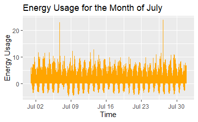

```r
# Load necessary libraries
library(readr)
library(dplyr)
library(ggplot2)

# Define the new path for the dataset
dataset_path <- "C:/Users/sagar/Downloads/IDS Project/final code/merged_all_dataset.csv"

# Load the dataset from the new path
final_dataset <- read_csv(dataset_path)
# Visualization 1: Time series plot of electricity consumption
# Filter the data to include only records for the month of July
july_data <- filter(final_dataset, month(date_time) == 7)

ggplot(july_data, aes(x = date_time, y = total_energy)) +
  geom_line(color = "orange") +
  labs(x = "Time", y = "Energy Usage", title = "Energy Usage for the Month of July")
```

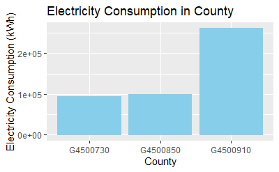

```r
# Visualization 2: Bar plot of electricity consumption in Counties
# Bar plot
ggplot(final_dataset, aes(x = in.county, y = electricity)) +
  geom_bar(stat = "identity", fill = "skyblue") +
  labs(x = "County", y = "Electricity Consumption (kWh)", title = "Electricity Consumption in County")
```

[figure not shown]

```r
library(ggplot2)

# Specify the columns of interest
columns_of_interest <- c("total_energy", "electricity", "fuel_oil", "natural_gas", "propane")

# Create bar plots for each column over time
bar_plots_over_time <- lapply(columns_of_interest, function(col) {
  ggplot(final_dataset, aes(x = date_time, y = !!sym(col))) +
    geom_bar(stat = "identity", color = "lightpink") +
    labs(x = "date_time", y = col, title = paste("Bar Plot of", col)) +
    theme_minimal()
})

# Arrange the bar plots in a grid
gridExtra::grid.arrange(grobs = bar_plots_over_time, ncol = 2)
```

### Step 8: Visualization of Energy Consumption by Type Over Time

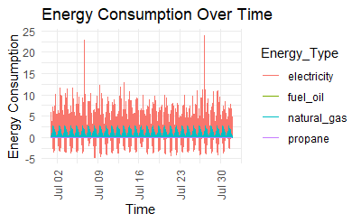

```r
# Load the necessary libraries
library(ggplot2)
library(readr)
library(reshape2)
# Load your dataset
#data <- read_csv("C:/Users/sagar/Downloads/IDS Project/final code/merged_all_dataset.csv")
july_data <- cleaned_merged_all_dataset %>%
  filter(month(date_time) == 7)

# Melt the data to long format for the energy types
energy_data <- melt(july_data,
                    id.vars = "date_time",
                    measure.vars = c("electricity", "fuel_oil", "natural_gas", "propane"),
                    variable.name = "Energy_Type",
                    value.name = "Consumption")

# Create a line plot
ggplot(energy_data, aes(x = date_time, y = Consumption, color = Energy_Type)) +
  geom_line() +
  labs(title = "Energy Consumption Over Time", x = "Time", y = "Energy Consumption") +
  theme_minimal() +
  theme(axis.text.x = element_text(angle = 90, hjust = 1, vjust = 0.5)) # Rotate x-axis labels for clarity
```

### Step 9: Visualizing Total Electricity Consumption over various factors before temperature increase

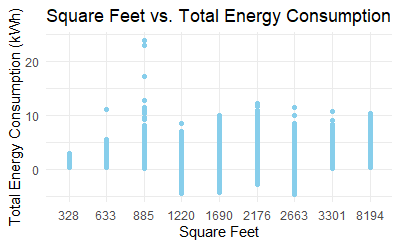

```r
# Load your dataset from a pre-defined location
merged_all_data <- read_csv("C:/Users/sagar/Downloads/IDS Project/final code/merged_all_dataset.csv")
# Plot: Square feet vs. Total Energy Consumption before temperature increase
ggplot(merged_all_data, aes(x = factor(in.sqft), y = total_energy)) +
  geom_point(color = "skyblue") +
  labs(x = "Square Feet", y = "Total Energy Consumption (kWh)") +
  ggtitle("Square Feet vs. Total Energy Consumption") +
  theme_minimal()
```

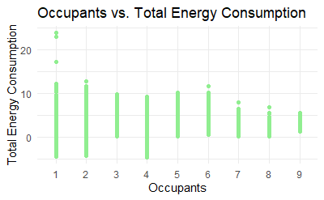

```r
# Plot 1: Total Energy Consumption vs. Occupants before temperature increase
ggplot(merged_all_data, aes(x = factor(in.occupants), y = total_energy)) +
  geom_point() +
  geom_point(color = "lightgreen") +
  labs(x = "Occupants", y = "Total Energy Consumption") +
  ggtitle("Occupants vs. Total Energy Consumption") +
  theme_minimal()
```

[figure not shown]

[figure not shown]

```r
# Load necessary libraries
library(ggplot2)
library(dplyr)
library(tidyr)  # For pivot_longer

# Assuming 'final_merged_dataset' is already loaded
data <- merged_all_data

# Ensure 'time' or equivalent column is in appropriate datetime format
data$date_time <- as.POSIXct(data$date_time, format = "%Y-%m-%d %H:%M:%S")

# Reshape data to long format for plotting
data_long <- pivot_longer(data,
                          cols = c("in.clothes_dryer", "in.clothes_washer", "in.dishwasher", "in.refrigerator"),
                          names_to = "Appliance",
                          values_to = "Status")

# Create a ggplot
ggplot(data_long, aes(x = date_time, y = Status, color = Appliance, group = Appliance)) +
  geom_line() +  # Change to geom_step() if status changes should be shown as steps
  labs(title = "Appliance Usage Over Time",
       x = "Time",
       y = "Usage/Status",
       color = "Appliance") +
  theme_minimal() +
  theme(axis.text.x = element_text(angle = 45, hjust = 1))  # Improve x-axis label readability
```

```r
# Note: Modify geom_line to another geom function if the data is not continuous.
```

```r
#Final loading and cleaning of merged_all_dataset for training and testing
library(caret)   # For data partitioning and pre-processing
library(dplyr)   # For data manipulation

# Load the data from the specified path
final_dataset <- read.csv('C:/Users/sagar/Downloads/IDS Project/final code/merged_all_dataset.csv')

#Cleaning and storing of final dataset
# Drop rows with any NA values
final_dataset <- na.omit(final_dataset)
# Identify columns with only a single unique value
single_value_columns <- sapply(final_dataset, function(column) length(unique(column)) == 1)
# Drop these columns
cleaned_final_data <- final_dataset[, !single_value_columns]
#write.csv(cleaned_final_data, "C:/Users/sagar/Downloads/IDS Project/final code/cleaned_final_data.csv", row.names = FALSE)

#increasing temperature by 5 degree
cleaned_final_data$Dry.Bulb.Temperature...C. <- cleaned_final_data$Dry.Bulb.Temperature...C.+ 5

# Convert specified variables to factors
categorical_variables_df <- c('in.county', 'in.city', 'in.clothes_dryer', 'in.clothes_washer', "in.refrigerator", 'in.dishwasher', 'in.heating_fuel', 'in.sqft', 'bldg_id')
cleaned_final_data[categorical_variables_df] <- lapply(cleaned_final_data[categorical_variables_df], as.factor)

# Create a new response variable 'total_energy_consumption'
cleaned_final_data$total_energy_consumption <- rowSums(cleaned_final_data[, c('electricity', 'natural_gas')], na.rm = TRUE)
```

```r
# Load necessary libraries
library(e1071)
library(caret)   # For data partitioning and pre-processing
library(dplyr)   # For data manipulation

# Load the data from the specified path
final_dataset <- read.csv('C:/Users/sagar/Downloads/IDS Project/final code/merged_all_dataset.csv')

#Cleaning and storing of final dataset
# Drop rows with any NA values
final_dataset <- na.omit(final_dataset)
# Identify columns with only a single unique value
single_value_columns <- sapply(final_dataset, function(column) length(unique(column)) == 1)
# Drop these columns
cleaned_final_data <- final_dataset[, !single_value_columns]
write.csv(cleaned_final_data, "C:/Users/sagar/Downloads/IDS Project/final code/cleaned_final_data.csv", row.names = FALSE)
```

### Step 11: Preparing and Modeling Energy Consumption Data with GLM

This R script preprocesses energy consumption data, ensuring all categorical variables have sufficient levels, and fits a Generalized Linear Model (GLM) to predict total energy consumption. It then evaluates the model’s performance using Root Mean Square Error (RMSE) to measure accuracy.

```r
# Install and load necessary libraries
library(caret)   # For data partitioning and pre-processing
library(dplyr)   # For data manipulation

#Cleaning and storing of final dataset
# Drop rows with any NA values
final_dataset <- na.omit(final_dataset)
# Identify columns with only a single unique value
single_value_columns <- sapply(final_dataset, function(column) length(unique(column)) == 1)
# Drop these columns
cleaned_final_data <- final_dataset[, !single_value_columns]
write.csv(cleaned_final_data, "C:/Users/sagar/Downloads/IDS Project/final code/cleaned_final_data.csv", row.names = FALSE)

cleaned_final_data$Dry.Bulb.Temperature...C. <- cleaned_final_data$Dry.Bulb.Temperature...C.+ 5

# Convert specified variables to factors
categorical_variables_df <- c('in.county', 'in.city', 'in.clothes_dryer', 'in.clothes_washer', "in.refrigerator", 'in.dishwasher', 'in.heating_fuel', 'in.sqft', 'bldg_id')
cleaned_final_data[categorical_variables_df] <- lapply(cleaned_final_data[categorical_variables_df], as.factor)

# Create a new response variable 'total_energy_consumption'
cleaned_final_data$total_energy_consumption <- rowSums(cleaned_final_data[, c('electricity', 'natural_gas')], na.rm = TRUE)

# Split the data into training and test sets
set.seed(123)
trainIndex <- createDataPartition(cleaned_final_data$total_energy_consumption, p = 0.8, list = FALSE)
trainData <- cleaned_final_data[trainIndex, ]
testData <- cleaned_final_data[-trainIndex, ]

# Train the GLM model
glmModel <- glm(total_energy_consumption ~ date_time + in.city + bldg_id + in.county + in.clothes_dryer + in.clothes_washer + in.dishwasher + in.refrigerator + in.occupants + in.sqft + in.heating_fuel, data = trainData, family = gaussian)

# Evaluate the model
glmPredictions <- predict(glmModel, newdata = testData)
glmRMSE <- sqrt(mean((glmPredictions - testData$total_energy_consumption)^2))
print(paste("GLM Model RMSE:", glmRMSE))
```

```
[1] "GLM Model RMSE: 0.525502728958794"
```

### Step 12: Visualizing Total Electricity Consumption over various factors after temperature increase

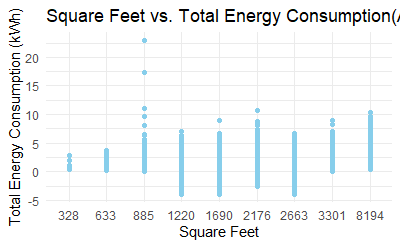

```r
library(ggplot2)
# Plot 2: Total Energy Consumption vs. Square feet after temperature increase
ggplot(testData, aes(x = factor(in.sqft), y = total_energy_consumption)) +
geom_point(color = "skyblue") +
labs(x = "Square Feet", y = "Total Energy Consumption (kWh)") +
ggtitle("Square Feet vs. Total Energy Consumption(After temp increase)") +
theme_minimal()
```

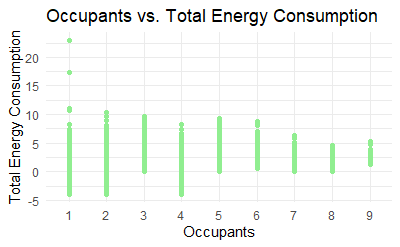

```r
# Plot 1: Total Energy Consumption vs. Occupants before temperature increase
ggplot(testData, aes(x = factor(in.occupants), y = total_energy)) +
  geom_point() +
  geom_point(color = "lightgreen") +
  labs(x = "Occupants", y = "Total Energy Consumption") +
  ggtitle("Occupants vs. Total Energy Consumption") +
  theme_minimal()
```

[figure not shown]

```r
# Load necessary libraries
library(ggplot2)
library(dplyr)
library(tidyr)  # For pivot_longer

# Assuming 'final_merged_dataset' is already loaded
data <- testData

# Ensure 'time' or equivalent column is in appropriate datetime format
data$date_time <- as.POSIXct(data$date_time, format = "%Y-%m-%d %H:%M:%S")

# Reshape data to long format for plotting
data_long <- pivot_longer(data,
                          cols = c("in.clothes_dryer", "in.clothes_washer", "in.dishwasher", "in.refrigerator"),
                          names_to = "Appliance",
                          values_to = "Status")

# Create a ggplot
ggplot(data_long, aes(x = date_time, y = Status, color = Appliance, group = Appliance)) +
  geom_line() +  # Change to geom_step() if status changes should be shown as steps
  labs(title = "Appliance Usage Over Time",
       x = "Time",
       y = "Usage/Status",
       color = "Appliance") +
  theme_minimal() +
  theme(axis.text.x = element_text(angle = 45, hjust = 1))  # Improve x-axis label readability
```